# Risk Factor Analysis

## Outcome Variable

**Outcome Variable:** ever_stunted

## Predictor Variables

**Intervention Variable:** tr

**Adjustment Set:**

unadjusted

## Stratifying Variables

The analysis was stratified on these variable(s):

- impsan
- agecat
- studyid
- country

## Data Summary

| impsan | agecat | studyid | country | tr | ever_stunted | n_cell | n |
| --- | --- | --- | --- | --- | --- | --- | --- |
| 0 | 0-6 months | ki1000110-WASH-Bangladesh | BANGLADESH | Control | 0 | 11 | 111 |
| 0 | 0-6 months | ki1000110-WASH-Bangladesh | BANGLADESH | Control | 1 | 6 | 111 |
| 0 | 0-6 months | ki1000110-WASH-Bangladesh | BANGLADESH | LNS | 0 | 35 | 111 |
| 0 | 0-6 months | ki1000110-WASH-Bangladesh | BANGLADESH | LNS | 1 | 4 | 111 |
| 0 | 0-6 months | ki1000110-WASH-Bangladesh | BANGLADESH | Other | 0 | 51 | 111 |
| 0 | 0-6 months | ki1000110-WASH-Bangladesh | BANGLADESH | Other | 1 | 4 | 111 |
| 1 | 0-6 months | ki1000110-WASH-Bangladesh | BANGLADESH | Control | 0 | 23 | 105 |
| 1 | 0-6 months | ki1000110-WASH-Bangladesh | BANGLADESH | Control | 1 | 0 | 105 |
| 1 | 0-6 months | ki1000110-WASH-Bangladesh | BANGLADESH | LNS | 0 | 23 | 105 |
| 1 | 0-6 months | ki1000110-WASH-Bangladesh | BANGLADESH | LNS | 1 | 3 | 105 |
| 1 | 0-6 months | ki1000110-WASH-Bangladesh | BANGLADESH | Other | 0 | 51 | 105 |
| 1 | 0-6 months | ki1000110-WASH-Bangladesh | BANGLADESH | Other | 1 | 5 | 105 |
| 0 | 0-6 months | ki1000111-WASH-Kenya | KENYA | Control | 0 | 10 | 41 |
| 0 | 0-6 months | ki1000111-WASH-Kenya | KENYA | Control | 1 | 2 | 41 |
| 0 | 0-6 months | ki1000111-WASH-Kenya | KENYA | LNS | 0 | 9 | 41 |
| 0 | 0-6 months | ki1000111-WASH-Kenya | KENYA | LNS | 1 | 0 | 41 |
| 0 | 0-6 months | ki1000111-WASH-Kenya | KENYA | Other | 0 | 18 | 41 |
| 0 | 0-6 months | ki1000111-WASH-Kenya | KENYA | Other | 1 | 2 | 41 |
| 1 | 0-6 months | ki1000111-WASH-Kenya | KENYA | Control | 0 | 2 | 27 |
| 1 | 0-6 months | ki1000111-WASH-Kenya | KENYA | Control | 1 | 0 | 27 |
| 1 | 0-6 months | ki1000111-WASH-Kenya | KENYA | LNS | 0 | 10 | 27 |
| 1 | 0-6 months | ki1000111-WASH-Kenya | KENYA | LNS | 1 | 0 | 27 |
| 1 | 0-6 months | ki1000111-WASH-Kenya | KENYA | Other | 0 | 12 | 27 |
| 1 | 0-6 months | ki1000111-WASH-Kenya | KENYA | Other | 1 | 3 | 27 |
| 0 | 0-6 months | ki1000125-AgaKhanUniv | PAKISTAN | Control | 0 | 26 | 77 |
| 0 | 0-6 months | ki1000125-AgaKhanUniv | PAKISTAN | Control | 1 | 12 | 77 |
| 0 | 0-6 months | ki1000125-AgaKhanUniv | PAKISTAN | Maternal | 0 | 31 | 77 |
| 0 | 0-6 months | ki1000125-AgaKhanUniv | PAKISTAN | Maternal | 1 | 8 | 77 |
| 1 | 0-6 months | ki1000125-AgaKhanUniv | PAKISTAN | Control | 0 | 9 | 20 |
| 1 | 0-6 months | ki1000125-AgaKhanUniv | PAKISTAN | Control | 1 | 0 | 20 |

[output cut: 324 more lines]

The following strata were considered:

- impsan: 0, agecat: 0-24 months, studyid: iLiNS_DYADM_LNS, country: MALAWI
- impsan: 0, agecat: 0-24 months, studyid: ki1000110-WASH-Bangladesh, country: BANGLADESH
- impsan: 0, agecat: 0-24 months, studyid: ki1000111-WASH-Kenya, country: KENYA
- impsan: 0, agecat: 0-24 months, studyid: ki1000125-AgaKhanUniv, country: PAKISTAN
- impsan: 0, agecat: 0-24 months, studyid: ki1000304-VITAMIN-A, country: INDIA
- impsan: 0, agecat: 0-24 months, studyid: ki1000304-ZnMort, country: INDIA
- impsan: 0, agecat: 0-24 months, studyid: ki1017093b-PROVIDE, country: BANGLADESH
- impsan: 0, agecat: 0-24 months, studyid: ki1112895-Burkina Faso Zn, country: BURKINA FASO
- impsan: 0, agecat: 0-24 months, studyid: ki1135781-COHORTS, country: GUATEMALA
- impsan: 0, agecat: 0-24 months, studyid: ki1148112-iLiNS-DOSE, country: MALAWI
- impsan: 0, agecat: 0-24 months, studyid: ki1148112-iLiNS-DYAD-M, country: MALAWI
- impsan: 0, agecat: 0-24 months, studyid: ki1148112-LCNI-5, country: MALAWI
- impsan: 0, agecat: 0-24 months, studyid: kiGH5241-JiVitA-3, country: BANGLADESH
- impsan: 0, agecat: 0-24 months, studyid: kiGH5241-JiVitA-4, country: BANGLADESH
- impsan: 0, agecat: 0-6 months, studyid: iLiNS_DYADM_LNS, country: MALAWI
- impsan: 0, agecat: 0-6 months, studyid: ki1000110-WASH-Bangladesh, country: BANGLADESH
- impsan: 0, agecat: 0-6 months, studyid: ki1000111-WASH-Kenya, country: KENYA
- impsan: 0, agecat: 0-6 months, studyid: ki1000125-AgaKhanUniv, country: PAKISTAN
- impsan: 0, agecat: 0-6 months, studyid: ki1000304-VITAMIN-A, country: INDIA
- impsan: 0, agecat: 0-6 months, studyid: ki1000304-ZnMort, country: INDIA
- impsan: 0, agecat: 0-6 months, studyid: ki1017093b-PROVIDE, country: BANGLADESH
- impsan: 0, agecat: 0-6 months, studyid: ki1112895-Burkina Faso Zn, country: BURKINA FASO
- impsan: 0, agecat: 0-6 months, studyid: ki1135781-COHORTS, country: GUATEMALA
- impsan: 0, agecat: 0-6 months, studyid: ki1148112-iLiNS-DOSE, country: MALAWI
- impsan: 0, agecat: 0-6 months, studyid: ki1148112-iLiNS-DYAD-M, country: MALAWI
- impsan: 0, agecat: 0-6 months, studyid: ki1148112-LCNI-5, country: MALAWI
- impsan: 0, agecat: 0-6 months, studyid: kiGH5241-JiVitA-3, country: BANGLADESH
- impsan: 0, agecat: 0-6 months, studyid: kiGH5241-JiVitA-4, country: BANGLADESH
- impsan: 0, agecat: 6-24 months, studyid: iLiNS_DYADM_LNS, country: MALAWI
- impsan: 0, agecat: 6-24 months, studyid: ki1000110-WASH-Bangladesh, country: BANGLADESH
- impsan: 0, agecat: 6-24 months, studyid: ki1000111-WASH-Kenya, country: KENYA
- impsan: 0, agecat: 6-24 months, studyid: ki1000125-AgaKhanUniv, country: PAKISTAN
- impsan: 0, agecat: 6-24 months, studyid: ki1000304-VITAMIN-A, country: INDIA
- impsan: 0, agecat: 6-24 months, studyid: ki1000304-ZnMort, country: INDIA
- impsan: 0, agecat: 6-24 months, studyid: ki1017093b-PROVIDE, country: BANGLADESH
- impsan: 0, agecat: 6-24 months, studyid: ki1112895-Burkina Faso Zn, country: BURKINA FASO
- impsan: 0, agecat: 6-24 months, studyid: ki1135781-COHORTS, country: GUATEMALA
- impsan: 0, agecat: 6-24 months, studyid: ki1148112-iLiNS-DOSE, country: MALAWI
- impsan: 0, agecat: 6-24 months, studyid: ki1148112-iLiNS-DYAD-M, country: MALAWI
- impsan: 0, agecat: 6-24 months, studyid: ki1148112-LCNI-5, country: MALAWI
- impsan: 0, agecat: 6-24 months, studyid: kiGH5241-JiVitA-3, country: BANGLADESH
- impsan: 0, agecat: 6-24 months, studyid: kiGH5241-JiVitA-4, country: BANGLADESH
- impsan: 1, agecat: 0-24 months, studyid: iLiNS_DYADM_LNS, country: MALAWI
- impsan: 1, agecat: 0-24 months, studyid: ki1000110-WASH-Bangladesh, country: BANGLADESH
- impsan: 1, agecat: 0-24 months, studyid: ki1000111-WASH-Kenya, country: KENYA
- impsan: 1, agecat: 0-24 months, studyid: ki1000125-AgaKhanUniv, country: PAKISTAN
- impsan: 1, agecat: 0-24 months, studyid: ki1000304-VITAMIN-A, country: INDIA
- impsan: 1, agecat: 0-24 months, studyid: ki1000304-ZnMort, country: INDIA
- impsan: 1, agecat: 0-24 months, studyid: ki1017093b-PROVIDE, country: BANGLADESH
- impsan: 1, agecat: 0-24 months, studyid: ki1112895-Burkina Faso Zn, country: BURKINA FASO
- impsan: 1, agecat: 0-24 months, studyid: ki1135781-COHORTS, country: GUATEMALA
- impsan: 1, agecat: 0-24 months, studyid: ki1148112-iLiNS-DOSE, country: MALAWI
- impsan: 1, agecat: 0-24 months, studyid: ki1148112-iLiNS-DYAD-M, country: MALAWI
- impsan: 1, agecat: 0-24 months, studyid: ki1148112-LCNI-5, country: MALAWI
- impsan: 1, agecat: 0-24 months, studyid: kiGH5241-JiVitA-3, country: BANGLADESH
- impsan: 1, agecat: 0-24 months, studyid: kiGH5241-JiVitA-4, country: BANGLADESH
- impsan: 1, agecat: 0-6 months, studyid: iLiNS_DYADM_LNS, country: MALAWI
- impsan: 1, agecat: 0-6 months, studyid: ki1000110-WASH-Bangladesh, country: BANGLADESH
- impsan: 1, agecat: 0-6 months, studyid: ki1000111-WASH-Kenya, country: KENYA
- impsan: 1, agecat: 0-6 months, studyid: ki1000125-AgaKhanUniv, country: PAKISTAN
- impsan: 1, agecat: 0-6 months, studyid: ki1000304-VITAMIN-A, country: INDIA
- impsan: 1, agecat: 0-6 months, studyid: ki1000304-ZnMort, country: INDIA
- impsan: 1, agecat: 0-6 months, studyid: ki1017093b-PROVIDE, country: BANGLADESH
- impsan: 1, agecat: 0-6 months, studyid: ki1112895-Burkina Faso Zn, country: BURKINA FASO
- impsan: 1, agecat: 0-6 months, studyid: ki1135781-COHORTS, country: GUATEMALA
- impsan: 1, agecat: 0-6 months, studyid: ki1148112-iLiNS-DOSE, country: MALAWI
- impsan: 1, agecat: 0-6 months, studyid: ki1148112-iLiNS-DYAD-M, country: MALAWI
- impsan: 1, agecat: 0-6 months, studyid: kiGH5241-JiVitA-3, country: BANGLADESH
- impsan: 1, agecat: 0-6 months, studyid: kiGH5241-JiVitA-4, country: BANGLADESH
- impsan: 1, agecat: 6-24 months, studyid: iLiNS_DYADM_LNS, country: MALAWI
- impsan: 1, agecat: 6-24 months, studyid: ki1000110-WASH-Bangladesh, country: BANGLADESH
- impsan: 1, agecat: 6-24 months, studyid: ki1000111-WASH-Kenya, country: KENYA
- impsan: 1, agecat: 6-24 months, studyid: ki1000125-AgaKhanUniv, country: PAKISTAN
- impsan: 1, agecat: 6-24 months, studyid: ki1000304-VITAMIN-A, country: INDIA
- impsan: 1, agecat: 6-24 months, studyid: ki1000304-ZnMort, country: INDIA
- impsan: 1, agecat: 6-24 months, studyid: ki1017093b-PROVIDE, country: BANGLADESH
- impsan: 1, agecat: 6-24 months, studyid: ki1112895-Burkina Faso Zn, country: BURKINA FASO
- impsan: 1, agecat: 6-24 months, studyid: ki1135781-COHORTS, country: GUATEMALA
- impsan: 1, agecat: 6-24 months, studyid: ki1148112-iLiNS-DOSE, country: MALAWI
- impsan: 1, agecat: 6-24 months, studyid: ki1148112-iLiNS-DYAD-M, country: MALAWI
- impsan: 1, agecat: 6-24 months, studyid: ki1148112-LCNI-5, country: MALAWI
- impsan: 1, agecat: 6-24 months, studyid: kiGH5241-JiVitA-3, country: BANGLADESH
- impsan: 1, agecat: 6-24 months, studyid: kiGH5241-JiVitA-4, country: BANGLADESH

### Dropped Strata

Some strata were dropped due to rare outcomes:

- impsan: 0, agecat: 0-6 months, studyid: ki1000110-WASH-Bangladesh, country: BANGLADESH
- impsan: 1, agecat: 0-6 months, studyid: ki1000110-WASH-Bangladesh, country: BANGLADESH
- impsan: 0, agecat: 0-6 months, studyid: ki1000111-WASH-Kenya, country: KENYA
- impsan: 1, agecat: 0-6 months, studyid: ki1000111-WASH-Kenya, country: KENYA
- impsan: 1, agecat: 0-6 months, studyid: ki1000125-AgaKhanUniv, country: PAKISTAN
- impsan: 0, agecat: 0-6 months, studyid: ki1017093b-PROVIDE, country: BANGLADESH
- impsan: 1, agecat: 0-6 months, studyid: ki1112895-Burkina Faso Zn, country: BURKINA FASO
- impsan: 1, agecat: 0-6 months, studyid: ki1135781-COHORTS, country: GUATEMALA
- impsan: 1, agecat: 0-6 months, studyid: ki1148112-iLiNS-DOSE, country: MALAWI
- impsan: 0, agecat: 0-6 months, studyid: ki1148112-iLiNS-DYAD-M, country: MALAWI
- impsan: 1, agecat: 0-6 months, studyid: ki1148112-iLiNS-DYAD-M, country: MALAWI
- impsan: 1, agecat: 6-24 months, studyid: ki1000125-AgaKhanUniv, country: PAKISTAN
- impsan: 0, agecat: 6-24 months, studyid: ki1000125-AgaKhanUniv, country: PAKISTAN
- impsan: 0, agecat: 6-24 months, studyid: ki1017093b-PROVIDE, country: BANGLADESH
- impsan: 1, agecat: 6-24 months, studyid: ki1148112-iLiNS-DOSE, country: MALAWI
- impsan: 1, agecat: 6-24 months, studyid: ki1148112-LCNI-5, country: MALAWI
- impsan: 1, agecat: 0-24 months, studyid: ki1000125-AgaKhanUniv, country: PAKISTAN
- impsan: 0, agecat: 0-24 months, studyid: ki1017093b-PROVIDE, country: BANGLADESH
- impsan: 1, agecat: 0-24 months, studyid: ki1148112-iLiNS-DOSE, country: MALAWI
- impsan: 1, agecat: 0-24 months, studyid: ki1148112-LCNI-5, country: MALAWI
- impsan: 0, agecat: 0-6 months, studyid: iLiNS_DYADM_LNS, country: MALAWI
- impsan: 1, agecat: 0-6 months, studyid: iLiNS_DYADM_LNS, country: MALAWI

## Methods Detail

We’re interested in the causal parameters $E[Y_a]$ for all values of $a \in \mathcal{A}$. These parameters represent the mean outcome if, possibly contrary to fact, we intervened to set all units to have $A=a$. Under the randomization and positivity assumptions, these are identified by the statistical parameters $\psi_a=E_W[E_{Y|A,W}(Y|A=a,W)]$. In addition, we’re interested in the mean of $Y$, $E[Y]$ under no intervention (the observed mean). We will estimate these parameters by using SuperLearner to fit the relevant likelihood factors – $E_{Y|A,W}(Y|A=a,W)$ and $p(A=a|W)$, and then updating our likelihood fit using a joint TMLE.

For unadjusted analyses ($W=\{\}$), initial likelihoods were estimated using Lrnr_glm to estimate the simple $E(Y|A)$ and Lrnr_mean to estimate $p(A)$. For adjusted analyses, a small library containing Lrnr_glmnet, Lrnr_xgboost, and Lrnr_mean was used.

Having estimated these parameters, we will then use the delta method to estimate relative risks and attributable risks relative to a prespecified baseline level of $A$.

[output not shown]

# Results Detail

## Results Plots

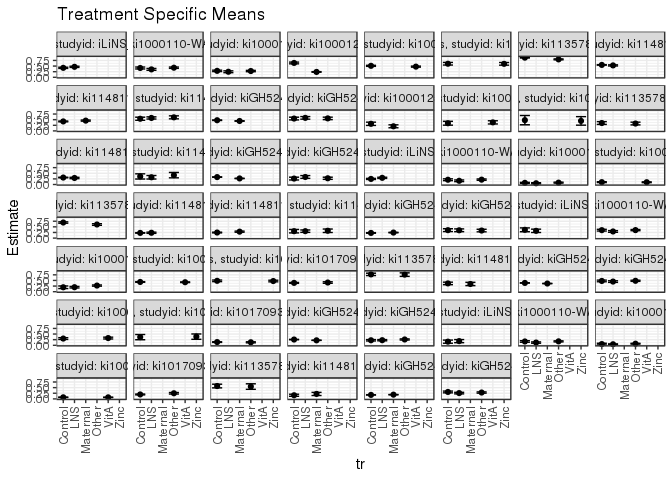

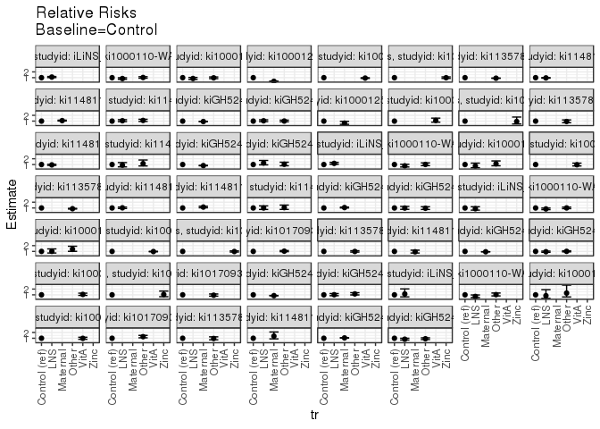

[figure not shown]

[figure not shown]

## Results Table

### Parameter: TSM

| impsan | agecat | studyid | country | intervention_level | baseline_level | estimate | ci_lower | ci_upper |
| --- | --- | --- | --- | --- | --- | --- | --- | --- |
| 0 | 0-24 months | iLiNS_DYADM_LNS | MALAWI | Control | NA | 0.4212034 | 0.3951345 | 0.4472724 |
| 0 | 0-24 months | iLiNS_DYADM_LNS | MALAWI | LNS | NA | 0.4666667 | 0.4404780 | 0.4928554 |
| 0 | 0-24 months | ki1000110-WASH-Bangladesh | BANGLADESH | Control | NA | 0.4142012 | 0.3713139 | 0.4570885 |
| 0 | 0-24 months | ki1000110-WASH-Bangladesh | BANGLADESH | LNS | NA | 0.3521401 | 0.3108382 | 0.3934419 |
| 0 | 0-24 months | ki1000110-WASH-Bangladesh | BANGLADESH | Other | NA | 0.4273504 | 0.3974639 | 0.4572369 |
| 0 | 0-24 months | ki1000111-WASH-Kenya | KENYA | Control | NA | 0.2873832 | 0.2570605 | 0.3177058 |
| 0 | 0-24 months | ki1000111-WASH-Kenya | KENYA | LNS | NA | 0.2471655 | 0.2068966 | 0.2874344 |
| 0 | 0-24 months | ki1000111-WASH-Kenya | KENYA | Other | NA | 0.2796158 | 0.2508724 | 0.3083592 |
| 0 | 0-24 months | ki1000125-AgaKhanUniv | PAKISTAN | Control | NA | 0.6383929 | 0.5999513 | 0.6768344 |
| 0 | 0-24 months | ki1000125-AgaKhanUniv | PAKISTAN | Maternal | NA | 0.2394366 | 0.2258444 | 0.2530289 |
| 0 | 0-24 months | ki1000304-VITAMIN-A | INDIA | Control | NA | 0.5103734 | 0.4873554 | 0.5333915 |
| 0 | 0-24 months | ki1000304-VITAMIN-A | INDIA | VitA | NA | 0.4746137 | 0.4523228 | 0.4969046 |
| 0 | 0-24 months | ki1000304-ZnMort | INDIA | Control | NA | 0.6035714 | 0.5462241 | 0.6609188 |
| 0 | 0-24 months | ki1000304-ZnMort | INDIA | Zinc | NA | 0.5992509 | 0.5404167 | 0.6580852 |
| 0 | 0-24 months | ki1135781-COHORTS | GUATEMALA | Control | NA | 0.8740360 | 0.8575388 | 0.8905332 |
| 0 | 0-24 months | ki1135781-COHORTS | GUATEMALA | Other | NA | 0.7969152 | 0.7769134 | 0.8169169 |
| 0 | 0-24 months | ki1148112-iLiNS-DOSE | MALAWI | Control | NA | 0.5509259 | 0.5397192 | 0.5621327 |
| 0 | 0-24 months | ki1148112-iLiNS-DOSE | MALAWI | LNS | NA | 0.5296331 | 0.5046860 | 0.5545802 |
| 0 | 0-24 months | ki1148112-iLiNS-DYAD-M | MALAWI | Control | NA | 0.4212034 | 0.4038450 | 0.4385619 |
| 0 | 0-24 months | ki1148112-iLiNS-DYAD-M | MALAWI | Maternal | NA | 0.4574315 | 0.4327514 | 0.4821115 |
| 0 | 0-24 months | ki1148112-LCNI-5 | MALAWI | Control | NA | 0.5404040 | 0.4709446 | 0.6098635 |
| 0 | 0-24 months | ki1148112-LCNI-5 | MALAWI | LNS | NA | 0.5759804 | 0.5279979 | 0.6239629 |
| 0 | 0-24 months | ki1148112-LCNI-5 | MALAWI | Other | NA | 0.6029412 | 0.5357571 | 0.6701252 |
| 0 | 0-24 months | kiGH5241-JiVitA-3 | BANGLADESH | Control | NA | 0.4746322 | 0.4641468 | 0.4851177 |
| 0 | 0-24 months | kiGH5241-JiVitA-3 | BANGLADESH | Maternal | NA | 0.4409562 | 0.4306964 | 0.4512161 |
| 0 | 0-24 months | kiGH5241-JiVitA-4 | BANGLADESH | Control | NA | 0.5489614 | 0.4883645 | 0.6095584 |
| 0 | 0-24 months | kiGH5241-JiVitA-4 | BANGLADESH | LNS | NA | 0.5802817 | 0.5225547 | 0.6380087 |
| 0 | 0-24 months | kiGH5241-JiVitA-4 | BANGLADESH | Other | NA | 0.5567766 | 0.5023671 | 0.6111860 |
| 0 | 0-6 months | ki1000125-AgaKhanUniv | PAKISTAN | Control | NA | 0.3157895 | 0.2423750 | 0.3892039 |
| 0 | 0-6 months | ki1000125-AgaKhanUniv | PAKISTAN | Maternal | NA | 0.2051282 | 0.1405197 | 0.2697367 |

[output cut: 95 more lines]

### Parameter: E(Y)

| impsan | agecat | studyid | country | intervention_level | baseline_level | estimate | ci_lower | ci_upper |
| --- | --- | --- | --- | --- | --- | --- | --- | --- |
| 0 | 0-24 months | iLiNS_DYADM_LNS | MALAWI | NA | NA | 0.4438040 | 0.4068135 | 0.4807946 |
| 0 | 0-24 months | ki1000110-WASH-Bangladesh | BANGLADESH | NA | NA | 0.4054966 | 0.3843608 | 0.4266325 |
| 0 | 0-24 months | ki1000111-WASH-Kenya | KENYA | NA | NA | 0.2761862 | 0.2576416 | 0.2947308 |
| 0 | 0-24 months | ki1000125-AgaKhanUniv | PAKISTAN | NA | NA | 0.5838150 | 0.5413664 | 0.6262637 |
| 0 | 0-24 months | ki1000304-VITAMIN-A | INDIA | NA | NA | 0.4930481 | 0.4609852 | 0.5251110 |
| 0 | 0-24 months | ki1000304-ZnMort | INDIA | NA | NA | 0.6014625 | 0.5603957 | 0.6425293 |
| 0 | 0-24 months | ki1135781-COHORTS | GUATEMALA | NA | NA | 0.8354756 | 0.8094069 | 0.8615443 |
| 0 | 0-24 months | ki1148112-iLiNS-DOSE | MALAWI | NA | NA | 0.5332291 | 0.5058769 | 0.5605812 |
| 0 | 0-24 months | ki1148112-iLiNS-DYAD-M | MALAWI | NA | NA | 0.4452975 | 0.4151065 | 0.4754885 |
| 0 | 0-24 months | ki1148112-LCNI-5 | MALAWI | NA | NA | 0.5740741 | 0.5399999 | 0.6081482 |
| 0 | 0-24 months | kiGH5241-JiVitA-3 | BANGLADESH | NA | NA | 0.4574452 | 0.4426916 | 0.4721989 |
| 0 | 0-24 months | kiGH5241-JiVitA-4 | BANGLADESH | NA | NA | 0.5613893 | 0.5279136 | 0.5948651 |
| 0 | 0-6 months | ki1000125-AgaKhanUniv | PAKISTAN | NA | NA | 0.2597403 | 0.1611570 | 0.3583235 |
| 0 | 0-6 months | ki1000304-VITAMIN-A | INDIA | NA | NA | 0.3561644 | 0.2455543 | 0.4667744 |
| 0 | 0-6 months | ki1000304-ZnMort | INDIA | NA | NA | 0.4600000 | 0.3204513 | 0.5995487 |
| 0 | 0-6 months | ki1135781-COHORTS | GUATEMALA | NA | NA | 0.3391304 | 0.2522270 | 0.4260339 |
| 0 | 0-6 months | ki1148112-iLiNS-DOSE | MALAWI | NA | NA | 0.2934132 | 0.2625111 | 0.3243152 |
| 0 | 0-6 months | ki1148112-LCNI-5 | MALAWI | NA | NA | 0.3531599 | 0.2959376 | 0.4103821 |
| 0 | 0-6 months | kiGH5241-JiVitA-3 | BANGLADESH | NA | NA | 0.2987465 | 0.2848193 | 0.3126737 |
| 0 | 0-6 months | kiGH5241-JiVitA-4 | BANGLADESH | NA | NA | 0.2894231 | 0.2570192 | 0.3218269 |
| 0 | 6-24 months | iLiNS_DYADM_LNS | MALAWI | NA | NA | 0.2717391 | 0.2345949 | 0.3088834 |
| 0 | 6-24 months | ki1000110-WASH-Bangladesh | BANGLADESH | NA | NA | 0.2016487 | 0.1818396 | 0.2214578 |
| 0 | 6-24 months | ki1000111-WASH-Kenya | KENYA | NA | NA | 0.0737515 | 0.0614032 | 0.0860997 |
| 0 | 6-24 months | ki1000304-VITAMIN-A | INDIA | NA | NA | 0.1028037 | 0.0770449 | 0.1285625 |
| 0 | 6-24 months | ki1135781-COHORTS | GUATEMALA | NA | NA | 0.6452442 | 0.5976385 | 0.6928499 |
| 0 | 6-24 months | ki1148112-iLiNS-DOSE | MALAWI | NA | NA | 0.2357724 | 0.2074025 | 0.2641422 |
| 0 | 6-24 months | ki1148112-iLiNS-DYAD-M | MALAWI | NA | NA | 0.2730539 | 0.2428168 | 0.3032910 |
| 0 | 6-24 months | ki1148112-LCNI-5 | MALAWI | NA | NA | 0.3123909 | 0.2744096 | 0.3503722 |
| 0 | 6-24 months | kiGH5241-JiVitA-3 | BANGLADESH | NA | NA | 0.2378929 | 0.2206701 | 0.2551158 |
| 0 | 6-24 months | kiGH5241-JiVitA-4 | BANGLADESH | NA | NA | 0.3437838 | 0.3086238 | 0.3789438 |
| 1 | 0-24 months | iLiNS_DYADM_LNS | MALAWI | NA | NA | 0.3478261 | 0.2346235 | 0.4610287 |
| 1 | 0-24 months | ki1000110-WASH-Bangladesh | BANGLADESH | NA | NA | 0.3395062 | 0.3206743 | 0.3583380 |
| 1 | 0-24 months | ki1000111-WASH-Kenya | KENYA | NA | NA | 0.2433526 | 0.2231264 | 0.2635789 |
| 1 | 0-24 months | ki1000304-VITAMIN-A | INDIA | NA | NA | 0.4263804 | 0.4073963 | 0.4453644 |
| 1 | 0-24 months | ki1000304-ZnMort | INDIA | NA | NA | 0.4781733 | 0.4527926 | 0.5035539 |
| 1 | 0-24 months | ki1017093b-PROVIDE | BANGLADESH | NA | NA | 0.4032787 | 0.3643179 | 0.4422395 |
| 1 | 0-24 months | ki1135781-COHORTS | GUATEMALA | NA | NA | 0.7625000 | 0.6686604 | 0.8563396 |
| 1 | 0-24 months | ki1148112-iLiNS-DYAD-M | MALAWI | NA | NA | 0.3523810 | 0.2605694 | 0.4441925 |
| 1 | 0-24 months | kiGH5241-JiVitA-3 | BANGLADESH | NA | NA | 0.3759310 | 0.3667934 | 0.3850685 |
| 1 | 0-24 months | kiGH5241-JiVitA-4 | BANGLADESH | NA | NA | 0.4731311 | 0.4548449 | 0.4914173 |
| 1 | 0-6 months | ki1000304-VITAMIN-A | INDIA | NA | NA | 0.3103448 | 0.2541107 | 0.3665789 |
| 1 | 0-6 months | ki1000304-ZnMort | INDIA | NA | NA | 0.3740458 | 0.2908675 | 0.4572241 |
| 1 | 0-6 months | ki1017093b-PROVIDE | BANGLADESH | NA | NA | 0.1362890 | 0.1090174 | 0.1635606 |
| 1 | 0-6 months | kiGH5241-JiVitA-3 | BANGLADESH | NA | NA | 0.2379412 | 0.2296293 | 0.2462531 |
| 1 | 0-6 months | kiGH5241-JiVitA-4 | BANGLADESH | NA | NA | 0.2405459 | 0.2247989 | 0.2562930 |
| 1 | 6-24 months | iLiNS_DYADM_LNS | MALAWI | NA | NA | 0.1724138 | 0.0743512 | 0.2704764 |
| 1 | 6-24 months | ki1000110-WASH-Bangladesh | BANGLADESH | NA | NA | 0.1597329 | 0.1434556 | 0.1760102 |
| 1 | 6-24 months | ki1000111-WASH-Kenya | KENYA | NA | NA | 0.0608255 | 0.0482152 | 0.0734358 |
| 1 | 6-24 months | ki1000304-VITAMIN-A | INDIA | NA | NA | 0.0686275 | 0.0563578 | 0.0808971 |
| 1 | 6-24 months | ki1017093b-PROVIDE | BANGLADESH | NA | NA | 0.2362869 | 0.1980042 | 0.2745696 |
| 1 | 6-24 months | ki1135781-COHORTS | GUATEMALA | NA | NA | 0.5555556 | 0.4087325 | 0.7023786 |
| 1 | 6-24 months | ki1148112-iLiNS-DYAD-M | MALAWI | NA | NA | 0.2000000 | 0.1168977 | 0.2831023 |
| 1 | 6-24 months | kiGH5241-JiVitA-3 | BANGLADESH | NA | NA | 0.1823023 | 0.1735651 | 0.1910395 |
| 1 | 6-24 months | kiGH5241-JiVitA-4 | BANGLADESH | NA | NA | 0.2821650 | 0.2632833 | 0.3010468 |

### Parameter: RR

| impsan | agecat | studyid | country | intervention_level | baseline_level | estimate | ci_lower | ci_upper |
| --- | --- | --- | --- | --- | --- | --- | --- | --- |
| 0 | 0-24 months | iLiNS_DYADM_LNS | MALAWI | Control | Control | 1.0000000 | 1.0000000 | 1.0000000 |
| 0 | 0-24 months | iLiNS_DYADM_LNS | MALAWI | LNS | Control | 1.1079365 | 1.0191344 | 1.2044763 |
| 0 | 0-24 months | ki1000110-WASH-Bangladesh | BANGLADESH | Control | Control | 1.0000000 | 1.0000000 | 1.0000000 |
| 0 | 0-24 months | ki1000110-WASH-Bangladesh | BANGLADESH | LNS | Control | 0.8501668 | 0.7270387 | 0.9941473 |
| 0 | 0-24 months | ki1000110-WASH-Bangladesh | BANGLADESH | Other | Control | 1.0317460 | 0.9105607 | 1.1690597 |
| 0 | 0-24 months | ki1000111-WASH-Kenya | KENYA | Control | Control | 1.0000000 | 1.0000000 | 1.0000000 |
| 0 | 0-24 months | ki1000111-WASH-Kenya | KENYA | LNS | Control | 0.8600557 | 0.7083172 | 1.0443002 |
| 0 | 0-24 months | ki1000111-WASH-Kenya | KENYA | Other | Control | 0.9729720 | 0.8397011 | 1.1273947 |
| 0 | 0-24 months | ki1000125-AgaKhanUniv | PAKISTAN | Control | Control | 1.0000000 | 1.0000000 | 1.0000000 |
| 0 | 0-24 months | ki1000125-AgaKhanUniv | PAKISTAN | Maternal | Control | 0.3750616 | 0.3452726 | 0.4074206 |
| 0 | 0-24 months | ki1000304-VITAMIN-A | INDIA | Control | Control | 1.0000000 | 1.0000000 | 1.0000000 |
| 0 | 0-24 months | ki1000304-VITAMIN-A | INDIA | VitA | Control | 0.9299341 | 0.8713113 | 0.9925012 |
| 0 | 0-24 months | ki1000304-ZnMort | INDIA | Control | Control | 1.0000000 | 1.0000000 | 1.0000000 |
| 0 | 0-24 months | ki1000304-ZnMort | INDIA | Zinc | Control | 0.9928418 | 0.8660519 | 1.1381937 |
| 0 | 0-24 months | ki1135781-COHORTS | GUATEMALA | Control | Control | 1.0000000 | 1.0000000 | 1.0000000 |
| 0 | 0-24 months | ki1135781-COHORTS | GUATEMALA | Other | Control | 0.9117647 | 0.8835766 | 0.9408521 |
| 0 | 0-24 months | ki1148112-iLiNS-DOSE | MALAWI | Control | Control | 1.0000000 | 1.0000000 | 1.0000000 |
| 0 | 0-24 months | ki1148112-iLiNS-DOSE | MALAWI | LNS | Control | 0.9613509 | 0.9132705 | 1.0119624 |
| 0 | 0-24 months | ki1148112-iLiNS-DYAD-M | MALAWI | Control | Control | 1.0000000 | 1.0000000 | 1.0000000 |
| 0 | 0-24 months | ki1148112-iLiNS-DYAD-M | MALAWI | Maternal | Control | 1.0860107 | 1.0147261 | 1.1623031 |
| 0 | 0-24 months | ki1148112-LCNI-5 | MALAWI | Control | Control | 1.0000000 | 1.0000000 | 1.0000000 |
| 0 | 0-24 months | ki1148112-LCNI-5 | MALAWI | LNS | Control | 1.0658329 | 0.9144692 | 1.2422503 |
| 0 | 0-24 months | ki1148112-LCNI-5 | MALAWI | Other | Control | 1.1157229 | 0.9411949 | 1.3226141 |
| 0 | 0-24 months | kiGH5241-JiVitA-3 | BANGLADESH | Control | Control | 1.0000000 | 1.0000000 | 1.0000000 |
| 0 | 0-24 months | kiGH5241-JiVitA-3 | BANGLADESH | Maternal | Control | 0.9290482 | 0.8996631 | 0.9593930 |
| 0 | 0-24 months | kiGH5241-JiVitA-4 | BANGLADESH | Control | Control | 1.0000000 | 1.0000000 | 1.0000000 |
| 0 | 0-24 months | kiGH5241-JiVitA-4 | BANGLADESH | LNS | Control | 1.0570537 | 0.9111664 | 1.2262990 |
| 0 | 0-24 months | kiGH5241-JiVitA-4 | BANGLADESH | Other | Control | 1.0142362 | 0.8752451 | 1.1752995 |
| 0 | 0-6 months | ki1000125-AgaKhanUniv | PAKISTAN | Control | Control | 1.0000000 | 1.0000000 | 1.0000000 |
| 0 | 0-6 months | ki1000125-AgaKhanUniv | PAKISTAN | Maternal | Control | 0.6495726 | 0.4391508 | 0.9608195 |

[output cut: 95 more lines]

### Parameter: PAR

| impsan | agecat | studyid | country | intervention_level | baseline_level | estimate | ci_lower | ci_upper |
| --- | --- | --- | --- | --- | --- | --- | --- | --- |
| 0 | 0-24 months | iLiNS_DYADM_LNS | MALAWI | Control | NA | 0.0226006 | -0.0036427 | 0.0488439 |
| 0 | 0-24 months | ki1000110-WASH-Bangladesh | BANGLADESH | Control | NA | -0.0087046 | -0.0459441 | 0.0285350 |
| 0 | 0-24 months | ki1000111-WASH-Kenya | KENYA | Control | NA | -0.0111970 | -0.0348348 | 0.0124409 |
| 0 | 0-24 months | ki1000125-AgaKhanUniv | PAKISTAN | Control | NA | -0.0545778 | -0.0725816 | -0.0365741 |
| 0 | 0-24 months | ki1000304-VITAMIN-A | INDIA | Control | NA | -0.0173253 | -0.0396457 | 0.0049950 |
| 0 | 0-24 months | ki1000304-ZnMort | INDIA | Control | NA | -0.0021089 | -0.0422128 | 0.0379950 |
| 0 | 0-24 months | ki1135781-COHORTS | GUATEMALA | Control | NA | -0.0385604 | -0.0587451 | -0.0183758 |
| 0 | 0-24 months | ki1148112-iLiNS-DOSE | MALAWI | Control | NA | -0.0176968 | -0.0426478 | 0.0072541 |
| 0 | 0-24 months | ki1148112-iLiNS-DYAD-M | MALAWI | Control | NA | 0.0240941 | -0.0006078 | 0.0487959 |
| 0 | 0-24 months | ki1148112-LCNI-5 | MALAWI | Control | NA | 0.0336700 | -0.0265542 | 0.0938943 |
| 0 | 0-24 months | kiGH5241-JiVitA-3 | BANGLADESH | Control | NA | -0.0171870 | -0.0276551 | -0.0067189 |
| 0 | 0-24 months | kiGH5241-JiVitA-4 | BANGLADESH | Control | NA | 0.0124279 | -0.0404253 | 0.0652811 |
| 0 | 0-6 months | ki1000125-AgaKhanUniv | PAKISTAN | Control | NA | -0.0560492 | -0.1218441 | 0.0097457 |
| 0 | 0-6 months | ki1000304-VITAMIN-A | INDIA | Control | NA | 0.0152553 | -0.0555185 | 0.0860291 |
| 0 | 0-6 months | ki1000304-ZnMort | INDIA | Control | NA | -0.0182609 | -0.1695089 | 0.1329872 |
| 0 | 0-6 months | ki1135781-COHORTS | GUATEMALA | Control | NA | -0.0117468 | -0.0729687 | 0.0494751 |
| 0 | 0-6 months | ki1148112-iLiNS-DOSE | MALAWI | Control | NA | -0.0154104 | -0.0436026 | 0.0127819 |
| 0 | 0-6 months | ki1148112-LCNI-5 | MALAWI | Control | NA | -0.0050491 | -0.1046188 | 0.0945205 |
| 0 | 0-6 months | kiGH5241-JiVitA-3 | BANGLADESH | Control | NA | -0.0308765 | -0.0403501 | -0.0214028 |
| 0 | 0-6 months | kiGH5241-JiVitA-4 | BANGLADESH | Control | NA | 0.0258852 | -0.0270767 | 0.0788471 |
| 0 | 6-24 months | iLiNS_DYADM_LNS | MALAWI | Control | NA | 0.0244273 | -0.0024753 | 0.0513299 |
| 0 | 6-24 months | ki1000110-WASH-Bangladesh | BANGLADESH | Control | NA | -0.0102376 | -0.0454082 | 0.0249330 |
| 0 | 6-24 months | ki1000111-WASH-Kenya | KENYA | Control | NA | 0.0001318 | -0.0156819 | 0.0159456 |
| 0 | 6-24 months | ki1000304-VITAMIN-A | INDIA | Control | NA | -0.0016739 | -0.0197392 | 0.0163915 |
| 0 | 6-24 months | ki1135781-COHORTS | GUATEMALA | Control | NA | -0.0474932 | -0.0835013 | -0.0114851 |
| 0 | 6-24 months | ki1148112-iLiNS-DOSE | MALAWI | Control | NA | 0.0050031 | -0.0209421 | 0.0309483 |
| 0 | 6-24 months | ki1148112-iLiNS-DYAD-M | MALAWI | Control | NA | 0.0257421 | 0.0006862 | 0.0507979 |
| 0 | 6-24 months | ki1148112-LCNI-5 | MALAWI | Control | NA | 0.0052481 | -0.0613375 | 0.0718336 |
| 0 | 6-24 months | kiGH5241-JiVitA-3 | BANGLADESH | Control | NA | 0.0086275 | -0.0032553 | 0.0205104 |
| 0 | 6-24 months | kiGH5241-JiVitA-4 | BANGLADESH | Control | NA | -0.0089294 | -0.0636485 | 0.0457897 |
| 1 | 0-24 months | iLiNS_DYADM_LNS | MALAWI | Control | NA | -0.0205950 | -0.0952647 | 0.0540748 |
| 1 | 0-24 months | ki1000110-WASH-Bangladesh | BANGLADESH | Control | NA | -0.0133366 | -0.0465005 | 0.0198272 |
| 1 | 0-24 months | ki1000111-WASH-Kenya | KENYA | Control | NA | 0.0467234 | -0.0091179 | 0.1025646 |
| 1 | 0-24 months | ki1000304-VITAMIN-A | INDIA | Control | NA | -0.0059073 | -0.0192926 | 0.0074780 |
| 1 | 0-24 months | ki1000304-ZnMort | INDIA | Control | NA | -0.0047735 | -0.0305496 | 0.0210025 |
| 1 | 0-24 months | ki1017093b-PROVIDE | BANGLADESH | Control | NA | 0.0119743 | -0.0215130 | 0.0454617 |
| 1 | 0-24 months | ki1135781-COHORTS | GUATEMALA | Control | NA | -0.0067308 | -0.0841938 | 0.0707323 |
| 1 | 0-24 months | ki1148112-iLiNS-DYAD-M | MALAWI | Control | NA | -0.0160401 | -0.0889707 | 0.0568905 |
| 1 | 0-24 months | kiGH5241-JiVitA-3 | BANGLADESH | Control | NA | -0.0126804 | -0.0190973 | -0.0062635 |
| 1 | 0-24 months | kiGH5241-JiVitA-4 | BANGLADESH | Control | NA | -0.0044535 | -0.0359365 | 0.0270295 |
| 1 | 0-6 months | ki1000304-VITAMIN-A | INDIA | Control | NA | 0.0111322 | -0.0295469 | 0.0518113 |
| 1 | 0-6 months | ki1000304-ZnMort | INDIA | Control | NA | 0.0104094 | -0.0721437 | 0.0929626 |
| 1 | 0-6 months | ki1017093b-PROVIDE | BANGLADESH | Control | NA | -0.0065681 | -0.0297891 | 0.0166528 |
| 1 | 0-6 months | kiGH5241-JiVitA-3 | BANGLADESH | Control | NA | -0.0176030 | -0.0234007 | -0.0118052 |
| 1 | 0-6 months | kiGH5241-JiVitA-4 | BANGLADESH | Control | NA | 0.0177078 | -0.0088565 | 0.0442720 |
| 1 | 6-24 months | iLiNS_DYADM_LNS | MALAWI | Control | NA | 0.0111235 | -0.0577497 | 0.0799966 |
| 1 | 6-24 months | ki1000110-WASH-Bangladesh | BANGLADESH | Control | NA | -0.0097231 | -0.0387222 | 0.0192759 |
| 1 | 6-24 months | ki1000111-WASH-Kenya | KENYA | Control | NA | 0.0071342 | -0.0273190 | 0.0415874 |
| 1 | 6-24 months | ki1000304-VITAMIN-A | INDIA | Control | NA | -0.0004231 | -0.0091010 | 0.0082548 |
| 1 | 6-24 months | ki1017093b-PROVIDE | BANGLADESH | Control | NA | 0.0395656 | 0.0058722 | 0.0732590 |
| 1 | 6-24 months | ki1135781-COHORTS | GUATEMALA | Control | NA | -0.0158730 | -0.1379596 | 0.1062136 |
| 1 | 6-24 months | ki1148112-iLiNS-DYAD-M | MALAWI | Control | NA | 0.0387097 | -0.0312535 | 0.1086728 |
| 1 | 6-24 months | kiGH5241-JiVitA-3 | BANGLADESH | Control | NA | 0.0058808 | -0.0004578 | 0.0122193 |
| 1 | 6-24 months | kiGH5241-JiVitA-4 | BANGLADESH | Control | NA | -0.0255273 | -0.0579342 | 0.0068796 |

### Parameter: PAF

| impsan | agecat | studyid | country | intervention_level | baseline_level | estimate | ci_lower | ci_upper |
| --- | --- | --- | --- | --- | --- | --- | --- | --- |
| 0 | 0-24 months | iLiNS_DYADM_LNS | MALAWI | Control | NA | 0.0509247 | -0.0069737 | 0.1054941 |
| 0 | 0-24 months | ki1000110-WASH-Bangladesh | BANGLADESH | Control | NA | -0.0214664 | -0.1175611 | 0.0663654 |
| 0 | 0-24 months | ki1000111-WASH-Kenya | KENYA | Control | NA | -0.0405414 | -0.1297366 | 0.0416117 |
| 0 | 0-24 months | ki1000125-AgaKhanUniv | PAKISTAN | Control | NA | -0.0934848 | -0.1283060 | -0.0597383 |
| 0 | 0-24 months | ki1000304-VITAMIN-A | INDIA | Control | NA | -0.0351392 | -0.0831070 | 0.0107042 |
| 0 | 0-24 months | ki1000304-ZnMort | INDIA | Control | NA | -0.0035063 | -0.0724495 | 0.0610049 |
| 0 | 0-24 months | ki1135781-COHORTS | GUATEMALA | Control | NA | -0.0461538 | -0.0717530 | -0.0211662 |
| 0 | 0-24 months | ki1148112-iLiNS-DOSE | MALAWI | Control | NA | -0.0331881 | -0.0826873 | 0.0140482 |
| 0 | 0-24 months | ki1148112-iLiNS-DYAD-M | MALAWI | Control | NA | 0.0541078 | 0.0001091 | 0.1051903 |
| 0 | 0-24 months | ki1148112-LCNI-5 | MALAWI | Control | NA | 0.0586510 | -0.0524238 | 0.1580028 |
| 0 | 0-24 months | kiGH5241-JiVitA-3 | BANGLADESH | Control | NA | -0.0375717 | -0.0615976 | -0.0140896 |
| 0 | 0-24 months | kiGH5241-JiVitA-4 | BANGLADESH | Control | NA | 0.0221378 | -0.0766013 | 0.1118211 |
| 0 | 0-6 months | ki1000125-AgaKhanUniv | PAKISTAN | Control | NA | -0.2157895 | -0.5740059 | 0.0609031 |
| 0 | 0-6 months | ki1000304-VITAMIN-A | INDIA | Control | NA | 0.0428322 | -0.1679163 | 0.2155514 |
| 0 | 0-6 months | ki1000304-ZnMort | INDIA | Control | NA | -0.0396975 | -0.4266647 | 0.2423090 |
| 0 | 0-6 months | ki1135781-COHORTS | GUATEMALA | Control | NA | -0.0346379 | -0.2394655 | 0.1363410 |
| 0 | 0-6 months | ki1148112-iLiNS-DOSE | MALAWI | Control | NA | -0.0525210 | -0.1586972 | 0.0439258 |
| 0 | 0-6 months | ki1148112-LCNI-5 | MALAWI | Control | NA | -0.0142969 | -0.3393199 | 0.2318503 |
| 0 | 0-6 months | kiGH5241-JiVitA-3 | BANGLADESH | Control | NA | -0.1033534 | -0.1390418 | -0.0687831 |
| 0 | 0-6 months | kiGH5241-JiVitA-4 | BANGLADESH | Control | NA | 0.0894371 | -0.1131990 | 0.2551873 |
| 0 | 6-24 months | iLiNS_DYADM_LNS | MALAWI | Control | NA | 0.0898925 | -0.0052595 | 0.1760379 |
| 0 | 6-24 months | ki1000110-WASH-Bangladesh | BANGLADESH | Control | NA | -0.0507695 | -0.2404560 | 0.1099107 |
| 0 | 6-24 months | ki1000111-WASH-Kenya | KENYA | Control | NA | 0.0017874 | -0.2374026 | 0.1947419 |
| 0 | 6-24 months | ki1000304-VITAMIN-A | INDIA | Control | NA | -0.0162822 | -0.2115503 | 0.1475141 |
| 0 | 6-24 months | ki1135781-COHORTS | GUATEMALA | Control | NA | -0.0736050 | -0.1353325 | -0.0152336 |
| 0 | 6-24 months | ki1148112-iLiNS-DOSE | MALAWI | Control | NA | 0.0212202 | -0.0926434 | 0.1232181 |
| 0 | 6-24 months | ki1148112-iLiNS-DYAD-M | MALAWI | Control | NA | 0.0942747 | 0.0070065 | 0.1738734 |
| 0 | 6-24 months | ki1148112-LCNI-5 | MALAWI | Control | NA | 0.0167997 | -0.2212154 | 0.2084256 |
| 0 | 6-24 months | kiGH5241-JiVitA-3 | BANGLADESH | Control | NA | 0.0362665 | -0.0131354 | 0.0832595 |
| 0 | 6-24 months | kiGH5241-JiVitA-4 | BANGLADESH | Control | NA | -0.0259739 | -0.1983827 | 0.1216309 |
| 1 | 0-24 months | iLiNS_DYADM_LNS | MALAWI | Control | NA | -0.0592105 | -0.3134201 | 0.1457973 |
| 1 | 0-24 months | ki1000110-WASH-Bangladesh | BANGLADESH | Control | NA | -0.0392825 | -0.1417047 | 0.0539515 |
| 1 | 0-24 months | ki1000111-WASH-Kenya | KENYA | Control | NA | 0.1919987 | -0.0730134 | 0.3915583 |
| 1 | 0-24 months | ki1000304-VITAMIN-A | INDIA | Control | NA | -0.0138546 | -0.0461902 | 0.0174817 |
| 1 | 0-24 months | ki1000304-ZnMort | INDIA | Control | NA | -0.0099828 | -0.0653549 | 0.0425112 |
| 1 | 0-24 months | ki1017093b-PROVIDE | BANGLADESH | Control | NA | 0.0296925 | -0.0543339 | 0.1070223 |
| 1 | 0-24 months | ki1135781-COHORTS | GUATEMALA | Control | NA | -0.0088272 | -0.1167037 | 0.0886281 |
| 1 | 0-24 months | ki1148112-iLiNS-DYAD-M | MALAWI | Control | NA | -0.0455192 | -0.2860731 | 0.1500403 |
| 1 | 0-24 months | kiGH5241-JiVitA-3 | BANGLADESH | Control | NA | -0.0337307 | -0.0515367 | -0.0162262 |
| 1 | 0-24 months | kiGH5241-JiVitA-4 | BANGLADESH | Control | NA | -0.0094128 | -0.0781820 | 0.0549701 |
| 1 | 0-6 months | ki1000304-VITAMIN-A | INDIA | Control | NA | 0.0358705 | -0.0992522 | 0.1543836 |
| 1 | 0-6 months | ki1000304-ZnMort | INDIA | Control | NA | 0.0278293 | -0.2199523 | 0.2252846 |
| 1 | 0-6 months | ki1017093b-PROVIDE | BANGLADESH | Control | NA | -0.0481928 | -0.2429852 | 0.1160730 |
| 1 | 0-6 months | kiGH5241-JiVitA-3 | BANGLADESH | Control | NA | -0.0739803 | -0.1005358 | -0.0480655 |
| 1 | 0-6 months | kiGH5241-JiVitA-4 | BANGLADESH | Control | NA | 0.0736150 | -0.0437430 | 0.1777773 |
| 1 | 6-24 months | iLiNS_DYADM_LNS | MALAWI | Control | NA | 0.0645161 | -0.3961905 | 0.3732015 |
| 1 | 6-24 months | ki1000110-WASH-Bangladesh | BANGLADESH | Control | NA | -0.0608713 | -0.2588029 | 0.1059380 |
| 1 | 6-24 months | ki1000111-WASH-Kenya | KENYA | Control | NA | 0.1172899 | -0.6759987 | 0.5350968 |
| 1 | 6-24 months | ki1000304-VITAMIN-A | INDIA | Control | NA | -0.0061652 | -0.1417912 | 0.1133506 |
| 1 | 6-24 months | ki1017093b-PROVIDE | BANGLADESH | Control | NA | 0.1674473 | 0.0390441 | 0.2786932 |
| 1 | 6-24 months | ki1135781-COHORTS | GUATEMALA | Control | NA | -0.0285714 | -0.2814145 | 0.1743818 |
| 1 | 6-24 months | ki1148112-iLiNS-DYAD-M | MALAWI | Control | NA | 0.1935484 | -0.1489167 | 0.4339327 |
| 1 | 6-24 months | kiGH5241-JiVitA-3 | BANGLADESH | Control | NA | 0.0322583 | -0.0019988 | 0.0653441 |
| 1 | 6-24 months | kiGH5241-JiVitA-4 | BANGLADESH | Control | NA | -0.0904693 | -0.2113565 | 0.0183540 |